# Assignment 3

2023-12-02

# O. Introduction

# 1. Data analysis

First of all, we must analize our data, so we’ll show its summary:

```r
data <- read.csv("cirrhosis.csv")
summary(data)
```

```
##        ID            N_Days        Status              Drug
##  Min.   :  1.0   Min.   :  41   Length:418         Length:418
##  1st Qu.:105.2   1st Qu.:1093   Class :character   Class :character
##  Median :209.5   Median :1730   Mode  :character   Mode  :character
##  Mean   :209.5   Mean   :1918
##  3rd Qu.:313.8   3rd Qu.:2614
##  Max.   :418.0   Max.   :4795
##
##       Age            Sex              Ascites          Hepatomegaly
##  Min.   : 9598   Length:418         Length:418         Length:418
##  1st Qu.:15644   Class :character   Class :character   Class :character
##  Median :18628   Mode  :character   Mode  :character   Mode  :character
##  Mean   :18533
##  3rd Qu.:21272
##  Max.   :28650
##
##    Spiders             Edema             Bilirubin       Cholesterol
##  Length:418         Length:418         Min.   : 0.300   Min.   : 120.0
##  Class :character   Class :character   1st Qu.: 0.800   1st Qu.: 249.5
##  Mode  :character   Mode  :character   Median : 1.400   Median : 309.5
##                                        Mean   : 3.221   Mean   : 369.5
##                                        3rd Qu.: 3.400   3rd Qu.: 400.0
##                                        Max.   :28.000   Max.   :1775.0
##                                                         NA's   :134
##     Albumin          Copper          Alk_Phos            SGOT
##  Min.   :1.960   Min.   :  4.00   Min.   :  289.0   Min.   : 26.35
##  1st Qu.:3.243   1st Qu.: 41.25   1st Qu.:  871.5   1st Qu.: 80.60
##  Median :3.530   Median : 73.00   Median : 1259.0   Median :114.70
##  Mean   :3.497   Mean   : 97.65   Mean   : 1982.7   Mean   :122.56
##  3rd Qu.:3.770   3rd Qu.:123.00   3rd Qu.: 1980.0   3rd Qu.:151.90
##  Max.   :4.640   Max.   :588.00   Max.   :13862.4   Max.   :457.25
##                  NA's   :108      NA's   :106       NA's   :106
##  Tryglicerides      Platelets      Prothrombin        Stage
##  Min.   : 33.00   Min.   : 62.0   Min.   : 9.00   Min.   :1.000
##  1st Qu.: 84.25   1st Qu.:188.5   1st Qu.:10.00   1st Qu.:2.000
##  Median :108.00   Median :251.0   Median :10.60   Median :3.000
##  Mean   :124.70   Mean   :257.0   Mean   :10.73   Mean   :3.024
##  3rd Qu.:151.00   3rd Qu.:318.0   3rd Qu.:11.10   3rd Qu.:4.000
##  Max.   :598.00   Max.   :721.0   Max.   :18.00   Max.   :4.000
##  NA's   :136      NA's   :11      NA's   :2       NA's   :6
```

After having a little look to it, we are going to show 6 first rows.

```r
head(data)
```

```
##   ID N_Days Status            Drug   Age Sex Ascites Hepatomegaly Spiders Edema
## 1  1    400      D D-penicillamine 21464   F       Y            Y       Y     Y
## 2  2   4500      C D-penicillamine 20617   F       N            Y       Y     N
## 3  3   1012      D D-penicillamine 25594   M       N            N       N     S
## 4  4   1925      D D-penicillamine 19994   F       N            Y       Y     S
## 5  5   1504     CL         Placebo 13918   F       N            Y       Y     N
## 6  6   2503      D         Placebo 24201   F       N            Y       N     N
##   Bilirubin Cholesterol Albumin Copper Alk_Phos   SGOT Tryglicerides Platelets
## 1      14.5         261    2.60    156   1718.0 137.95           172       190
## 2       1.1         302    4.14     54   7394.8 113.52            88       221
## 3       1.4         176    3.48    210    516.0  96.10            55       151
## 4       1.8         244    2.54     64   6121.8  60.63            92       183
## 5       3.4         279    3.53    143    671.0 113.15            72       136
## 6       0.8         248    3.98     50    944.0  93.00            63        NA
##   Prothrombin Stage
## 1        12.2     4
## 2        10.6     3
## 3        12.0     4
## 4        10.3     4
## 5        10.9     3
## 6        11.0     3
```

It looks like we have a both numerical and categorical variables. Status,Drug, Sex, Ascites, Spiders and Edema are categorical variables that we’ll convert to numerical after analyzing the whole dataset.

## 1.2 Plotting data values

As we want to predict status variable we’ll plot this one along with other columns to see it’s relationship.

### 1.2.1 N_Days

First of all we are going to show the distribution of the number of days between registration and the earlier of death, transplantation, or study analysis time, in an histogram:

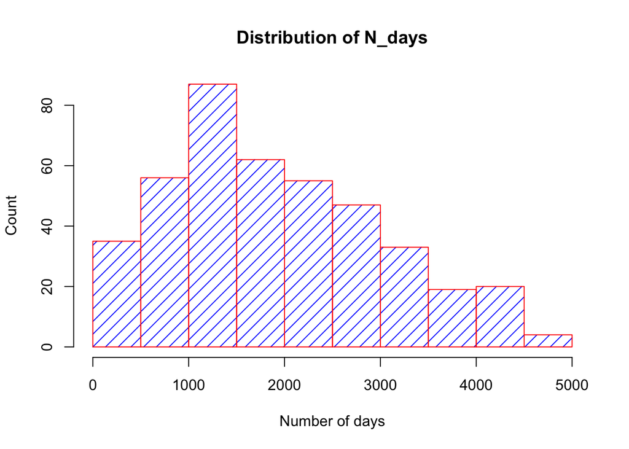

```r
hist(data$N_Days,main="Distribution of N_days",xlab="Number of days",ylab="Count", border="red",col="blue",density=10)
```

```r
mean_D <- mean(data[data$Status=='D',]$N_Days)
mean_C <- mean(data[data$Status=='C',]$N_Days)
mean_CL <- mean(data[data$Status=='CL',]$N_Days)

table <- data.frame(
  Variable = c("Mean(D)", "Mean(C)", "Mean(CL)"),
  Days_Mean = c(mean_D, mean_C, mean_CL)
)
print(table)
```

```
##   Variable Days_Mean
## 1  Mean(D)  1376.932
## 2  Mean(C)  2333.155
## 3 Mean(CL)  1546.200
```

### 1.2.2 Status

Now, let’s plot what our desired prediction value looks like. Let’s show how many values of each status we have. Let’s start with an histogram plot:

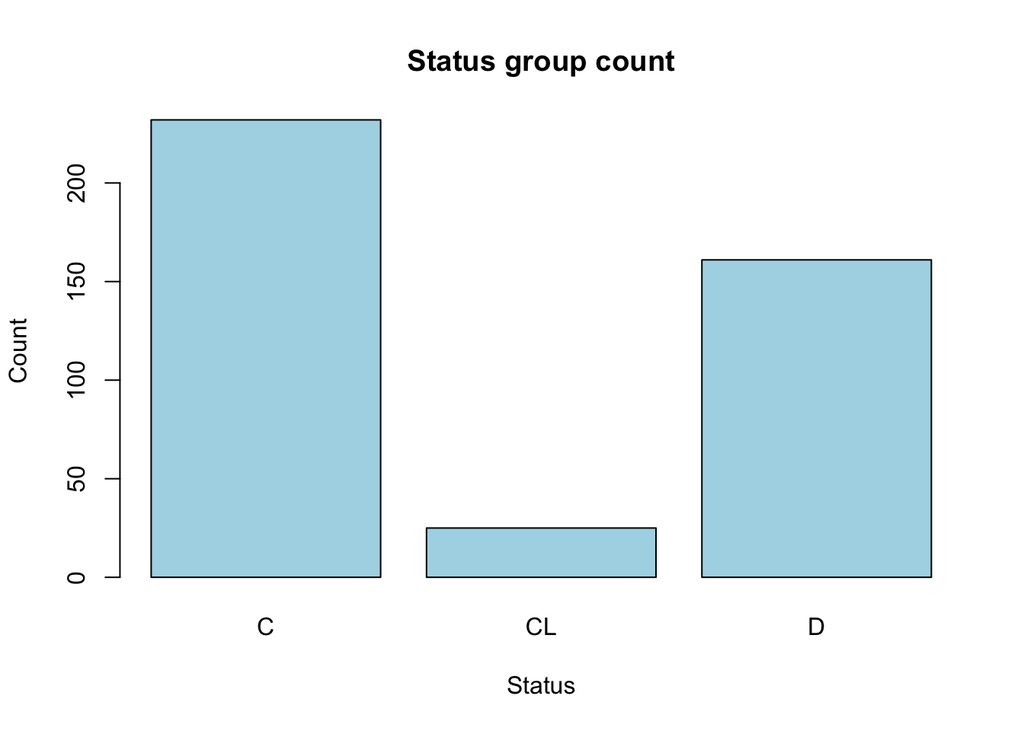

```r
# Extract the 'cyl' column (replace it with your actual categorical column)
categorical_column <- data$Status

# Create a table of frequencies
frequency_table <- table(categorical_column)

# Create the histogram for the frequency of each status
barplot(frequency_table, main = "Status group count", xlab = "Status", ylab = "Count", col = "lightblue")
```

Now we have seen the number of values for each status. To see the percentage of each one, we are going to plot another histogram:

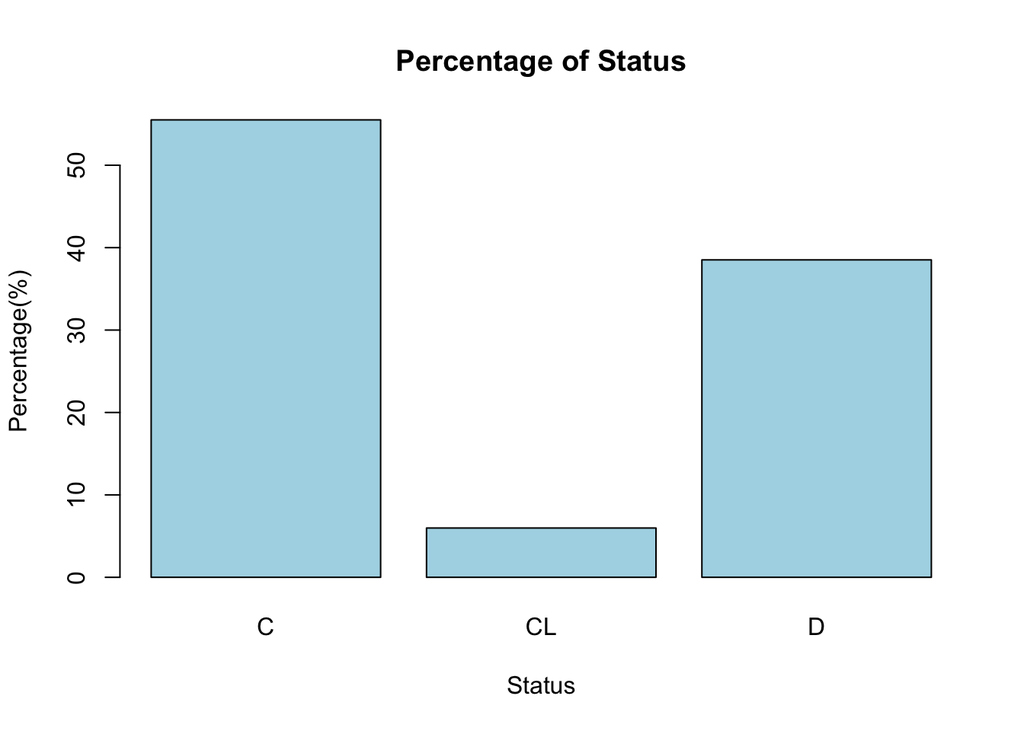

```r
# Calculate percentage values
percentage_values <- prop.table(frequency_table) * 100

# Create a barplot with percentage values on the y-axis
barplot(percentage_values, main = "Percentage of Status", xlab = "Status", ylab = "Percentage(%)", col = "lightblue")
```

#### 1.2.3 Drug

Now let’s analize the Drug column and see how many “Placebos” and “D-penicillamine” counts we have in the data set

```r
categorical_column <- data$Drug

# Create a table of frequencies
frequency_table <- table(categorical_column)
frequency_table
```

```
## categorical_column
## D-penicillamine         Placebo
##             158             154
```

Now we are going to show patients status that where treated with Placebo or D-penicillamine. With that we will see how many patients that where treated with an specific drug, finished dying or not:

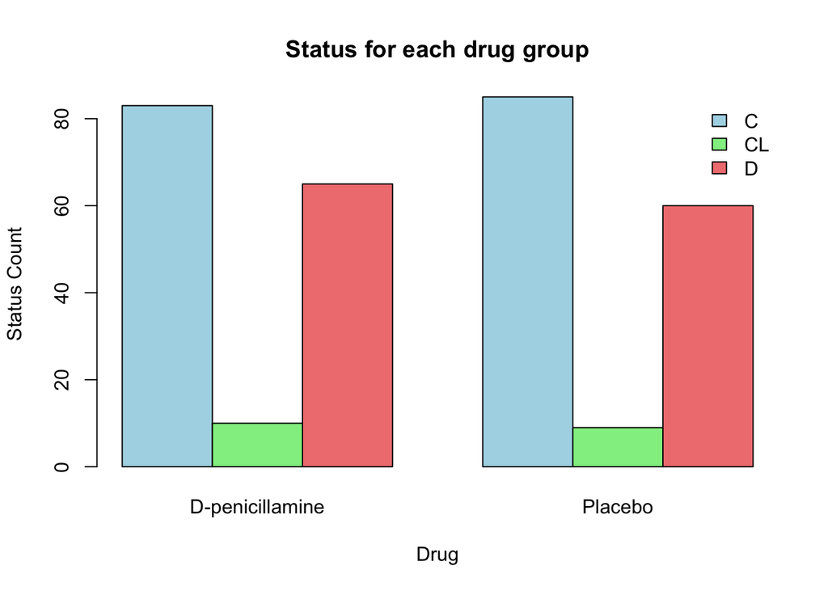

```r
# Create a table of counts
count_table <- table(data$Status, data$Drug)

# Create a bar plot
barplot(count_table, beside = TRUE, col = c("lightblue", "lightgreen", "lightcoral"),
        main = "Status for each drug group", xlab = "Drug", ylab = "Status Count",
        legend = rownames(count_table), args.legend = list(x = "topright", bty = "n"))
```

Drug variable doesn’t seem to be a very significant factor of death causes.

#### 1.2.4 Age

Now let’s analize patients age:

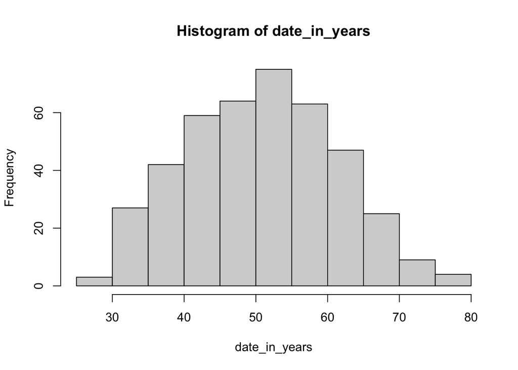

```r
date_in_years <- data$Age / 365.25
hist(date_in_years)
```

As we can see, in the main, patients had between 40 and 60 years.

#### 1.2.5 Sex

Now, let’s see how sex is distributed in this data set:

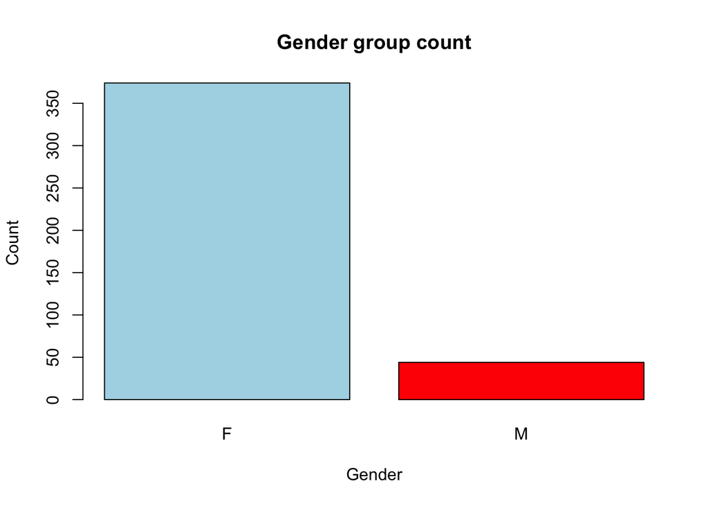

```r
# Extract the 'cyl' column (replace it with your actual categorical column)
categorical_column <- data$Sex

# Create a table of frequencies
frequency_table <- table(categorical_column)
barplot(frequency_table, main = "Gender group count", xlab = "Gender", ylab = "Count", col = c("lightblue","red"))
```

As we can see, most of patients where womans. Now we are going to look for each gender status distribution:

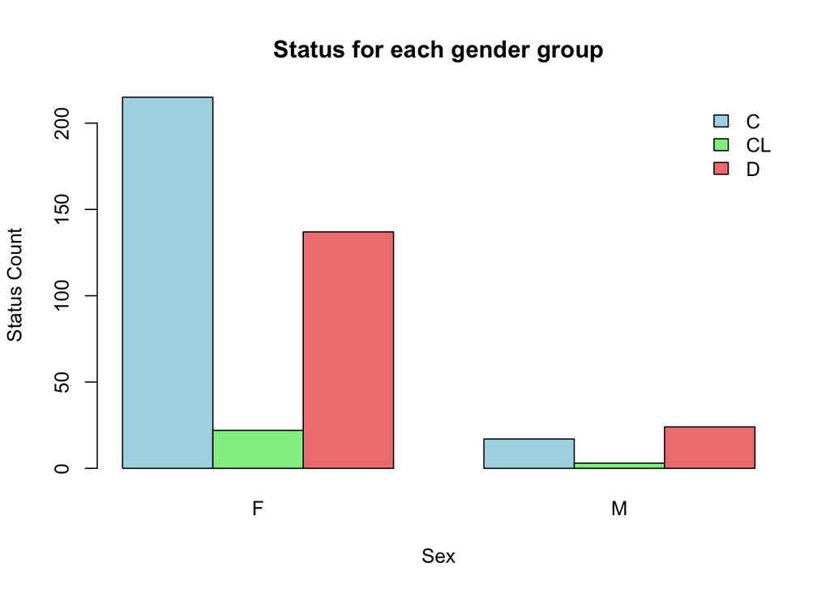

```r
# Create a table of counts
count_table <- table(data$Status, data$Sex)

# Create a bar plot
barplot(count_table, beside = TRUE, col = c("lightblue", "lightgreen", "lightcoral"),
        main = "Status for each gender group", xlab = "Sex", ylab = "Status Count",
        legend = rownames(count_table), args.legend = list(x = "topright", bty = "n"))
```

#### 1.2.6 Edema

Let’s see how the Edema column is distributed over the diferent status:

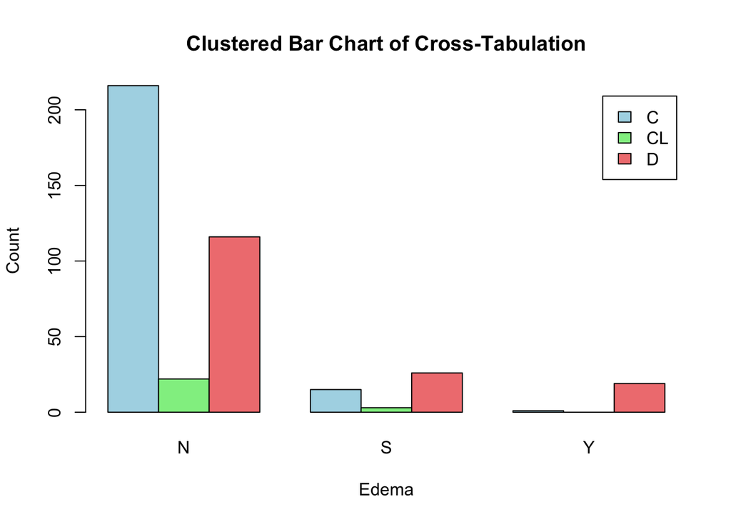

```r
Xtab <- table(data$Status, data$Edema)

# Define colors for each Status level
status_colors <- c("lightblue", "lightgreen", "lightcoral")

# Plot a clustered bar chart with specified colors
barplot(Xtab, beside = TRUE, col = status_colors,
        main = "Clustered Bar Chart of Cross-Tabulation",
        xlab = "Edema", ylab = "Count", legend = rownames(Xtab))
```

```r
# Perform the chi-square test
chi_result <- chisq.test(Xtab)
# Output the results
cat("Cross-Tabulation:\n")
```

```
## Cross-Tabulation:
```

```r
print(Xtab)
```

```
##
##        N   S   Y
##   C  216  15   1
##   CL  22   3   0
##   D  116  26  19
```

```r
cat("P-value:", chi_result$p.value, "\n")
```

```
## P-value: 3.438281e-08
```

We can conclude that most patients had no edema.

#### 1.2.7 Ascites

Now, let’s study how Ascites columns is distributed:

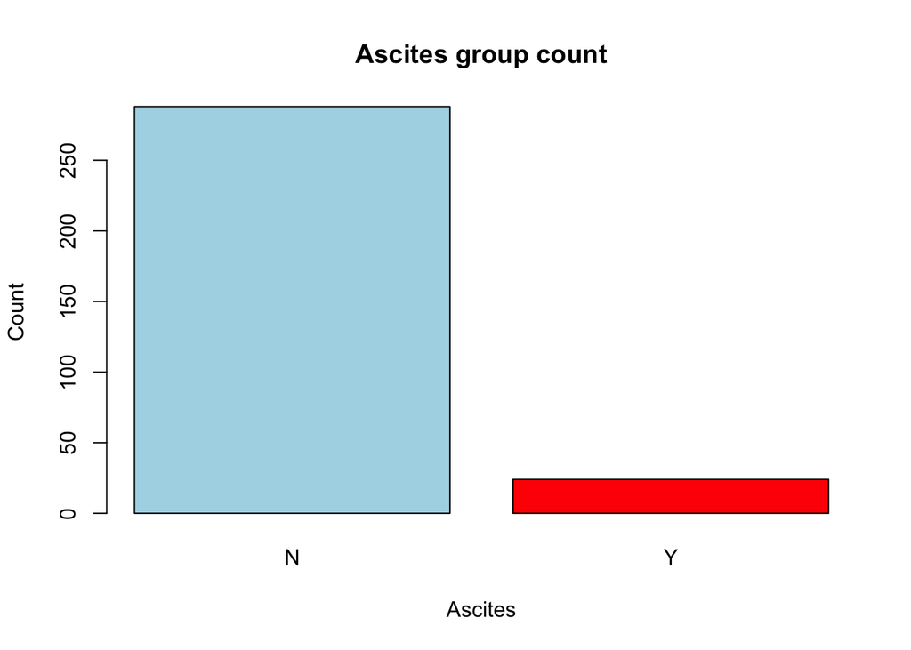

```r
# Extract the 'cyl' column (replace it with your actual categorical column)
categorical_column <- data$Ascites

# Create a table of frequencies
frequency_table <- table(categorical_column)
barplot(frequency_table, main = "Ascites group count", xlab = "Ascites", ylab = "Count", col = c("lightblue","red"))
```

As we can see, most patients had no Ascites.

[figure not shown]

```r
# Create a table of counts
count_table <- table(data$Status, data$Ascites)

# Create a bar plot
barplot(count_table, beside = TRUE, col = c("lightblue", "lightgreen", "lightcoral"),
        main = "Status for each gender group", xlab = "Ascites", ylab = "Status Count",
        legend = rownames(count_table), args.legend = list(x = "topright", bty = "n"))
```

Because most patients had no Ascites, the distribution of the status doesn’t give us much valuable information.

#### 1.2.8 Hepatomegaly

How Hepatomegaly column is distributed. Let’s find it out:

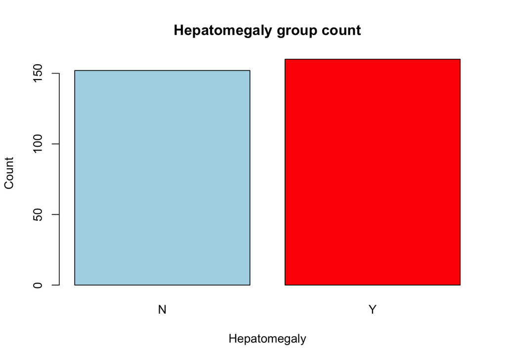

```r
# Extract the 'cyl' column (replace it with your actual categorical column)
categorical_column <- data$Hepatomegaly

# Create a table of frequencies
frequency_table <- table(categorical_column)
barplot(frequency_table, main = "Hepatomegaly group count", xlab = "Hepatomegaly", ylab = "Count", col = c("lightblue","red"))
```

Approximately, half of the patients had hepatomegaly so is a ver freqüent symptom. Now let’s see if the distribution of the status for patients that had hepatomegaly tells us something:

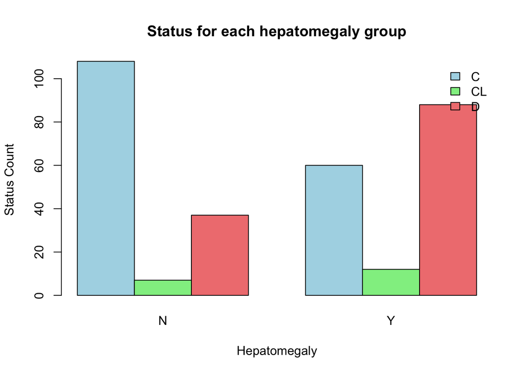

```r
# Create a table of counts
count_table <- table(data$Status, data$Hepatomegaly)

# Create a bar plot
barplot(count_table, beside = TRUE, col = c("lightblue", "lightgreen", "lightcoral"),
        main = "Status for each hepatomegaly group", xlab = "Hepatomegaly", ylab = "Status Count",
        legend = rownames(count_table), args.legend = list(x = "topright", bty = "n"))
```

We can see that the once they had hepatomegaly, had a higher mortality rate.

#### 1.2.9 Spiders

Let’s do the same for spider column:

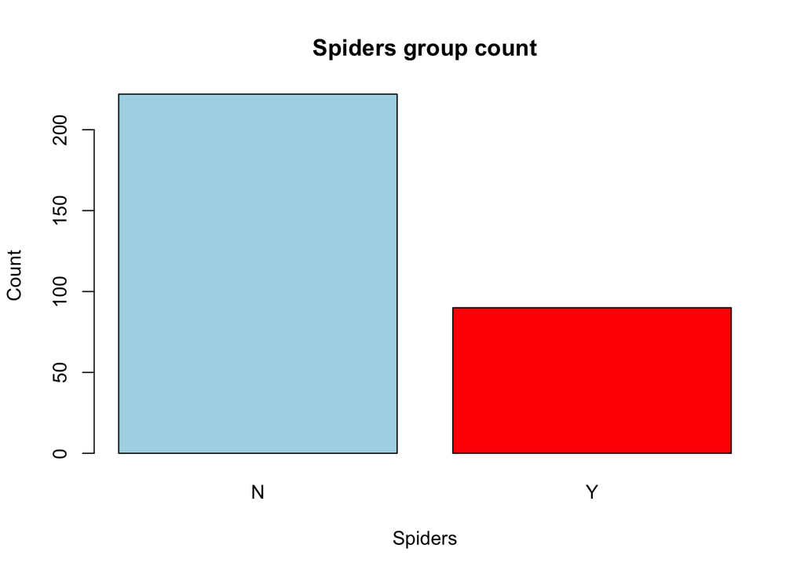

```r
# Extract the 'cyl' column (replace it with your actual categorical column)
categorical_column <- data$Spiders

# Create a table of frequencies
frequency_table <- table(categorical_column)
barplot(frequency_table, main = "Spiders group count", xlab = "Spiders", ylab = "Count", col = c("lightblue","red"))
```

Just a sample of the patients had spiders. Let’s see the distribution for each status.

[figure not shown]

```r
# Create a table of counts
count_table <- table(data$Status, data$Spiders)

# Create a bar plot
barplot(count_table, beside = TRUE, col = c("lightblue", "lightgreen", "lightcoral"),
        main = "Status for each spiders group", xlab = "Ascites", ylab = "Status Count",
        legend = rownames(count_table), args.legend = list(x = "topright", bty = "n"))
```

As we could see in Hepatomegaly column, patients that had spiders symptom, had a more chances of dying.

#### 1.2.10 Stage

Now let’s study how stage column is distributed:

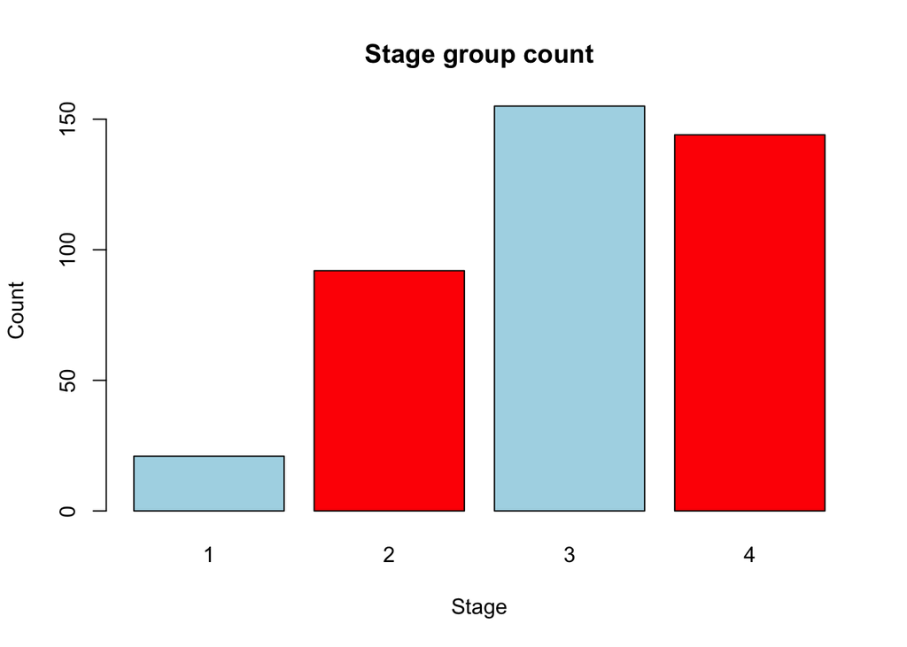

```r
# Extract the 'cyl' column (replace it with your actual categorical column)
categorical_column <- data$Stage

# Create a table of frequencies
frequency_table <- table(categorical_column)
barplot(frequency_table, main = "Stage group count", xlab = "Stage", ylab = "Count", col = c("lightblue","red"))
```

We can see that most patients had a 3 or 4 histologic stage.

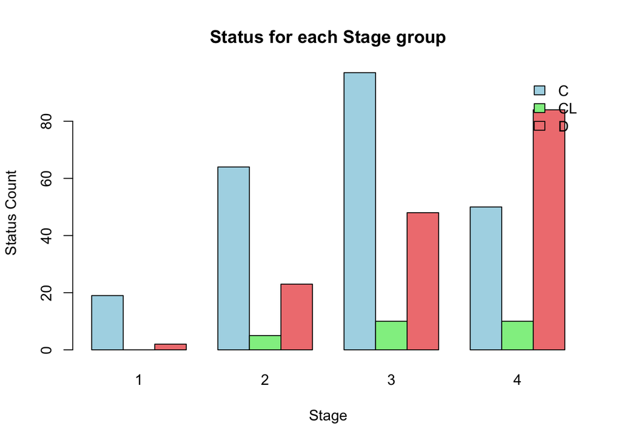

```r
# Create a table of counts
count_table <- table(data$Status, data$Stage)

# Create a bar plot
barplot(count_table, beside = TRUE, col = c("lightblue", "lightgreen", "lightcoral"),
        main = "Status for each Stage group", xlab = "Stage", ylab = "Status Count",
        legend = rownames(count_table), args.legend = list(x = "topright", bty = "n"))
```

# 2.Data cleaning

```r
na_summary_func <- function(data) {
  # Calculate the count of NA values for each column
  na_counts <- colSums(is.na(data))

  # Create a data frame with column names and their respective NA counts
  na_summary <- data.frame(Column = names(na_counts), NA_Count = na_counts)

  # Keep only columns with NA counts greater than 0
  na_summary <- na_summary[na_summary$NA_Count > 0,]

  # Print the data frame
  print(na_summary)

  # Return the resulting data frame (optional)
  return(na_summary)
}
```

## 2.1 Missing values

```r
# Calculate the count of NA values for each column
na_counts <- colSums(is.na(data))

# Create a data frame with column names and their respective NA counts
na_summary <- data.frame(Column = names(na_counts), NA_Count = na_counts)
na_summary <- na_summary[na_summary$NA_Count>0,]

# Print the data frame
print(na_summary)
```

```
##                      Column NA_Count
## Drug                   Drug      106
## Ascites             Ascites      106
## Hepatomegaly   Hepatomegaly      106
## Spiders             Spiders      106
## Cholesterol     Cholesterol      134
## Copper               Copper      108
## Alk_Phos           Alk_Phos      106
## SGOT                   SGOT      106
## Tryglicerides Tryglicerides      136
## Platelets         Platelets       11
## Prothrombin     Prothrombin        2
## Stage                 Stage        6
```

```r
data <- data[complete.cases(data$Drug),]
print(data)
```

[output not shown]

[output cut: 924 more lines]

After cleaning our dataset where Drug value is NA, let’s check if the problem has been solved:

```r
na_summary_func(data)
```

```
##                      Column NA_Count
## Cholesterol     Cholesterol       28
## Copper               Copper        2
## Tryglicerides Tryglicerides       30
## Platelets         Platelets        4
```

```
##                      Column NA_Count
## Cholesterol     Cholesterol       28
## Copper               Copper        2
## Tryglicerides Tryglicerides       30
## Platelets         Platelets        4
```

## 2.2 Feature engineering

In this assignment, we want to predict whether a patient is dead or not. In our case, we have 3 labels: dead, censored and censored due to liver transplant. We can join both censored types into one label that would equal ‘alive’.

# 3. Classification tasks

## 3.1 Perceptron

## 3.2 Decision trees

## 3.3 NN-Nearest Neighbours

## 3.4 Naive-Bayes

## 4. Conclusion